# Risk Factor Analysis

## Outcome Variable

**Outcome Variable:** ever_wasted

## Predictor Variables

**Intervention Variable:** birthlen

**Adjustment Set:**

- arm
- sex
- W_mage
- meducyrs
- feducyrs
- vagbrth
- single
- brthmon
- W_parity
- delta_W_mage
- delta_meducyrs
- delta_feducyrs
- delta_vagbrth
- delta_single
- delta_brthmon
- delta_W_parity

## Stratifying Variables

The analysis was stratified on these variable(s):

- agecat
- studyid
- country

## Data Summary

| agecat | studyid | country | birthlen | ever_wasted | n_cell | n |
| --- | --- | --- | --- | --- | --- | --- |
| 0-24 months (no birth wast) | ki0047075b-MAL-ED | BANGLADESH | >=50 cm | 0 | 31 | 229 |
| 0-24 months (no birth wast) | ki0047075b-MAL-ED | BANGLADESH | >=50 cm | 1 | 8 | 229 |
| 0-24 months (no birth wast) | ki0047075b-MAL-ED | BANGLADESH | <48 cm | 0 | 80 | 229 |
| 0-24 months (no birth wast) | ki0047075b-MAL-ED | BANGLADESH | <48 cm | 1 | 31 | 229 |
| 0-24 months (no birth wast) | ki0047075b-MAL-ED | BANGLADESH | [48-50) cm | 0 | 64 | 229 |
| 0-24 months (no birth wast) | ki0047075b-MAL-ED | BANGLADESH | [48-50) cm | 1 | 15 | 229 |
| 0-24 months (no birth wast) | ki0047075b-MAL-ED | BRAZIL | >=50 cm | 0 | 29 | 65 |
| 0-24 months (no birth wast) | ki0047075b-MAL-ED | BRAZIL | >=50 cm | 1 | 1 | 65 |
| 0-24 months (no birth wast) | ki0047075b-MAL-ED | BRAZIL | <48 cm | 0 | 15 | 65 |
| 0-24 months (no birth wast) | ki0047075b-MAL-ED | BRAZIL | <48 cm | 1 | 2 | 65 |
| 0-24 months (no birth wast) | ki0047075b-MAL-ED | BRAZIL | [48-50) cm | 0 | 17 | 65 |
| 0-24 months (no birth wast) | ki0047075b-MAL-ED | BRAZIL | [48-50) cm | 1 | 1 | 65 |
| 0-24 months (no birth wast) | ki0047075b-MAL-ED | INDIA | >=50 cm | 0 | 6 | 47 |
| 0-24 months (no birth wast) | ki0047075b-MAL-ED | INDIA | >=50 cm | 1 | 3 | 47 |
| 0-24 months (no birth wast) | ki0047075b-MAL-ED | INDIA | <48 cm | 0 | 11 | 47 |
| 0-24 months (no birth wast) | ki0047075b-MAL-ED | INDIA | <48 cm | 1 | 9 | 47 |
| 0-24 months (no birth wast) | ki0047075b-MAL-ED | INDIA | [48-50) cm | 0 | 10 | 47 |
| 0-24 months (no birth wast) | ki0047075b-MAL-ED | INDIA | [48-50) cm | 1 | 8 | 47 |
| 0-24 months (no birth wast) | ki0047075b-MAL-ED | NEPAL | >=50 cm | 0 | 7 | 27 |
| 0-24 months (no birth wast) | ki0047075b-MAL-ED | NEPAL | >=50 cm | 1 | 1 | 27 |
| 0-24 months (no birth wast) | ki0047075b-MAL-ED | NEPAL | <48 cm | 0 | 9 | 27 |
| 0-24 months (no birth wast) | ki0047075b-MAL-ED | NEPAL | <48 cm | 1 | 3 | 27 |
| 0-24 months (no birth wast) | ki0047075b-MAL-ED | NEPAL | [48-50) cm | 0 | 5 | 27 |
| 0-24 months (no birth wast) | ki0047075b-MAL-ED | NEPAL | [48-50) cm | 1 | 2 | 27 |
| 0-24 months (no birth wast) | ki0047075b-MAL-ED | PERU | >=50 cm | 0 | 49 | 233 |
| 0-24 months (no birth wast) | ki0047075b-MAL-ED | PERU | >=50 cm | 1 | 3 | 233 |
| 0-24 months (no birth wast) | ki0047075b-MAL-ED | PERU | <48 cm | 0 | 79 | 233 |
| 0-24 months (no birth wast) | ki0047075b-MAL-ED | PERU | <48 cm | 1 | 9 | 233 |
| 0-24 months (no birth wast) | ki0047075b-MAL-ED | PERU | [48-50) cm | 0 | 86 | 233 |
| 0-24 months (no birth wast) | ki0047075b-MAL-ED | PERU | [48-50) cm | 1 | 7 | 233 |

[output cut: 438 more lines]

The following strata were considered:

- agecat: 0-24 months (no birth wast), studyid: ki0047075b-MAL-ED, country: BANGLADESH
- agecat: 0-24 months (no birth wast), studyid: ki0047075b-MAL-ED, country: BRAZIL
- agecat: 0-24 months (no birth wast), studyid: ki0047075b-MAL-ED, country: INDIA
- agecat: 0-24 months (no birth wast), studyid: ki0047075b-MAL-ED, country: NEPAL
- agecat: 0-24 months (no birth wast), studyid: ki0047075b-MAL-ED, country: PERU
- agecat: 0-24 months (no birth wast), studyid: ki0047075b-MAL-ED, country: SOUTH AFRICA
- agecat: 0-24 months (no birth wast), studyid: ki0047075b-MAL-ED, country: TANZANIA, UNITED REPUBLIC OF
- agecat: 0-24 months (no birth wast), studyid: ki1000108-CMC-V-BCS-2002, country: INDIA
- agecat: 0-24 months (no birth wast), studyid: ki1000108-IRC, country: INDIA
- agecat: 0-24 months (no birth wast), studyid: ki1000109-EE, country: PAKISTAN
- agecat: 0-24 months (no birth wast), studyid: ki1000109-ResPak, country: PAKISTAN
- agecat: 0-24 months (no birth wast), studyid: ki1000304b-SAS-CompFeed, country: INDIA
- agecat: 0-24 months (no birth wast), studyid: ki1017093-NIH-Birth, country: BANGLADESH
- agecat: 0-24 months (no birth wast), studyid: ki1017093b-PROVIDE, country: BANGLADESH
- agecat: 0-24 months (no birth wast), studyid: ki1017093c-NIH-Crypto, country: BANGLADESH
- agecat: 0-24 months (no birth wast), studyid: ki1101329-Keneba, country: GAMBIA
- agecat: 0-24 months (no birth wast), studyid: ki1113344-GMS-Nepal, country: NEPAL
- agecat: 0-24 months (no birth wast), studyid: ki1114097-CMIN, country: BANGLADESH
- agecat: 0-24 months (no birth wast), studyid: ki1114097-CONTENT, country: PERU
- agecat: 0-24 months (no birth wast), studyid: ki1119695-PROBIT, country: BELARUS
- agecat: 0-24 months (no birth wast), studyid: ki1126311-ZVITAMBO, country: ZIMBABWE
- agecat: 0-24 months (no birth wast), studyid: ki1135781-COHORTS, country: GUATEMALA
- agecat: 0-24 months (no birth wast), studyid: ki1135781-COHORTS, country: INDIA
- agecat: 0-24 months (no birth wast), studyid: ki1135781-COHORTS, country: PHILIPPINES
- agecat: 0-24 months (no birth wast), studyid: kiGH5241-JiVitA-3, country: BANGLADESH
- agecat: 0-24 months (no birth wast), studyid: kiGH5241-JiVitA-4, country: BANGLADESH
- agecat: 0-6 months (no birth wast), studyid: ki0047075b-MAL-ED, country: BANGLADESH
- agecat: 0-6 months (no birth wast), studyid: ki0047075b-MAL-ED, country: BRAZIL
- agecat: 0-6 months (no birth wast), studyid: ki0047075b-MAL-ED, country: INDIA
- agecat: 0-6 months (no birth wast), studyid: ki0047075b-MAL-ED, country: NEPAL
- agecat: 0-6 months (no birth wast), studyid: ki0047075b-MAL-ED, country: PERU
- agecat: 0-6 months (no birth wast), studyid: ki0047075b-MAL-ED, country: SOUTH AFRICA
- agecat: 0-6 months (no birth wast), studyid: ki0047075b-MAL-ED, country: TANZANIA, UNITED REPUBLIC OF
- agecat: 0-6 months (no birth wast), studyid: ki1000108-CMC-V-BCS-2002, country: INDIA
- agecat: 0-6 months (no birth wast), studyid: ki1000108-IRC, country: INDIA
- agecat: 0-6 months (no birth wast), studyid: ki1000109-EE, country: PAKISTAN
- agecat: 0-6 months (no birth wast), studyid: ki1000109-ResPak, country: PAKISTAN
- agecat: 0-6 months (no birth wast), studyid: ki1000304b-SAS-CompFeed, country: INDIA
- agecat: 0-6 months (no birth wast), studyid: ki1017093-NIH-Birth, country: BANGLADESH
- agecat: 0-6 months (no birth wast), studyid: ki1017093b-PROVIDE, country: BANGLADESH
- agecat: 0-6 months (no birth wast), studyid: ki1017093c-NIH-Crypto, country: BANGLADESH
- agecat: 0-6 months (no birth wast), studyid: ki1101329-Keneba, country: GAMBIA
- agecat: 0-6 months (no birth wast), studyid: ki1113344-GMS-Nepal, country: NEPAL
- agecat: 0-6 months (no birth wast), studyid: ki1114097-CMIN, country: BANGLADESH
- agecat: 0-6 months (no birth wast), studyid: ki1114097-CONTENT, country: PERU
- agecat: 0-6 months (no birth wast), studyid: ki1119695-PROBIT, country: BELARUS
- agecat: 0-6 months (no birth wast), studyid: ki1126311-ZVITAMBO, country: ZIMBABWE
- agecat: 0-6 months (no birth wast), studyid: ki1135781-COHORTS, country: GUATEMALA
- agecat: 0-6 months (no birth wast), studyid: ki1135781-COHORTS, country: INDIA
- agecat: 0-6 months (no birth wast), studyid: ki1135781-COHORTS, country: PHILIPPINES
- agecat: 0-6 months (no birth wast), studyid: kiGH5241-JiVitA-3, country: BANGLADESH
- agecat: 0-6 months (no birth wast), studyid: kiGH5241-JiVitA-4, country: BANGLADESH
- agecat: 6-24 months, studyid: ki0047075b-MAL-ED, country: BANGLADESH
- agecat: 6-24 months, studyid: ki0047075b-MAL-ED, country: BRAZIL
- agecat: 6-24 months, studyid: ki0047075b-MAL-ED, country: INDIA
- agecat: 6-24 months, studyid: ki0047075b-MAL-ED, country: NEPAL
- agecat: 6-24 months, studyid: ki0047075b-MAL-ED, country: PERU
- agecat: 6-24 months, studyid: ki0047075b-MAL-ED, country: SOUTH AFRICA
- agecat: 6-24 months, studyid: ki0047075b-MAL-ED, country: TANZANIA, UNITED REPUBLIC OF
- agecat: 6-24 months, studyid: ki1000108-CMC-V-BCS-2002, country: INDIA
- agecat: 6-24 months, studyid: ki1000108-IRC, country: INDIA
- agecat: 6-24 months, studyid: ki1000109-EE, country: PAKISTAN
- agecat: 6-24 months, studyid: ki1000109-ResPak, country: PAKISTAN
- agecat: 6-24 months, studyid: ki1000304b-SAS-CompFeed, country: INDIA
- agecat: 6-24 months, studyid: ki1017093-NIH-Birth, country: BANGLADESH
- agecat: 6-24 months, studyid: ki1017093b-PROVIDE, country: BANGLADESH
- agecat: 6-24 months, studyid: ki1017093c-NIH-Crypto, country: BANGLADESH
- agecat: 6-24 months, studyid: ki1101329-Keneba, country: GAMBIA
- agecat: 6-24 months, studyid: ki1113344-GMS-Nepal, country: NEPAL
- agecat: 6-24 months, studyid: ki1114097-CMIN, country: BANGLADESH
- agecat: 6-24 months, studyid: ki1114097-CONTENT, country: PERU
- agecat: 6-24 months, studyid: ki1119695-PROBIT, country: BELARUS
- agecat: 6-24 months, studyid: ki1126311-ZVITAMBO, country: ZIMBABWE
- agecat: 6-24 months, studyid: ki1135781-COHORTS, country: GUATEMALA
- agecat: 6-24 months, studyid: ki1135781-COHORTS, country: INDIA
- agecat: 6-24 months, studyid: ki1135781-COHORTS, country: PHILIPPINES
- agecat: 6-24 months, studyid: kiGH5241-JiVitA-3, country: BANGLADESH
- agecat: 6-24 months, studyid: kiGH5241-JiVitA-4, country: BANGLADESH

### Dropped Strata

Some strata were dropped due to rare outcomes:

- agecat: 0-24 months (no birth wast), studyid: ki0047075b-MAL-ED, country: BRAZIL
- agecat: 0-24 months (no birth wast), studyid: ki0047075b-MAL-ED, country: INDIA
- agecat: 0-24 months (no birth wast), studyid: ki0047075b-MAL-ED, country: NEPAL
- agecat: 0-24 months (no birth wast), studyid: ki0047075b-MAL-ED, country: PERU
- agecat: 0-24 months (no birth wast), studyid: ki0047075b-MAL-ED, country: SOUTH AFRICA
- agecat: 0-24 months (no birth wast), studyid: ki0047075b-MAL-ED, country: TANZANIA, UNITED REPUBLIC OF
- agecat: 0-24 months (no birth wast), studyid: ki1114097-CMIN, country: BANGLADESH
- agecat: 0-24 months (no birth wast), studyid: ki1114097-CONTENT, country: PERU
- agecat: 0-6 months (no birth wast), studyid: ki0047075b-MAL-ED, country: BANGLADESH
- agecat: 0-6 months (no birth wast), studyid: ki0047075b-MAL-ED, country: BRAZIL
- agecat: 0-6 months (no birth wast), studyid: ki0047075b-MAL-ED, country: INDIA
- agecat: 0-6 months (no birth wast), studyid: ki0047075b-MAL-ED, country: NEPAL
- agecat: 0-6 months (no birth wast), studyid: ki0047075b-MAL-ED, country: PERU
- agecat: 0-6 months (no birth wast), studyid: ki0047075b-MAL-ED, country: SOUTH AFRICA
- agecat: 0-6 months (no birth wast), studyid: ki0047075b-MAL-ED, country: TANZANIA, UNITED REPUBLIC OF
- agecat: 0-6 months (no birth wast), studyid: ki1000109-ResPak, country: PAKISTAN
- agecat: 0-6 months (no birth wast), studyid: ki1114097-CMIN, country: BANGLADESH
- agecat: 0-6 months (no birth wast), studyid: ki1114097-CONTENT, country: PERU
- agecat: 6-24 months, studyid: ki0047075b-MAL-ED, country: BRAZIL
- agecat: 6-24 months, studyid: ki0047075b-MAL-ED, country: INDIA
- agecat: 6-24 months, studyid: ki0047075b-MAL-ED, country: NEPAL
- agecat: 6-24 months, studyid: ki0047075b-MAL-ED, country: PERU
- agecat: 6-24 months, studyid: ki0047075b-MAL-ED, country: SOUTH AFRICA
- agecat: 6-24 months, studyid: ki0047075b-MAL-ED, country: TANZANIA, UNITED REPUBLIC OF
- agecat: 6-24 months, studyid: ki1000108-CMC-V-BCS-2002, country: INDIA
- agecat: 6-24 months, studyid: ki1000109-ResPak, country: PAKISTAN
- agecat: 6-24 months, studyid: ki1114097-CMIN, country: BANGLADESH
- agecat: 6-24 months, studyid: ki1114097-CONTENT, country: PERU
- agecat: 6-24 months, studyid: ki1119695-PROBIT, country: BELARUS

## Methods Detail

We’re interested in the causal parameters $E[Y_a]$ for all values of $a \in \mathcal{A}$. These parameters represent the mean outcome if, possibly contrary to fact, we intervened to set all units to have $A=a$. Under the randomization and positivity assumptions, these are identified by the statistical parameters $\psi_a=E_W[E_{Y|A,W}(Y|A=a,W)]$. In addition, we’re interested in the mean of $Y$, $E[Y]$ under no intervention (the observed mean). We will estimate these parameters by using SuperLearner to fit the relevant likelihood factors – $E_{Y|A,W}(Y|A=a,W)$ and $p(A=a|W)$, and then updating our likelihood fit using a joint TMLE.

For unadjusted analyses ($W=\{\}$), initial likelihoods were estimated using Lrnr_glm to estimate the simple $E(Y|A)$ and Lrnr_mean to estimate $p(A)$. For adjusted analyses, a small library containing Lrnr_glmnet, Lrnr_xgboost, and Lrnr_mean was used.

Having estimated these parameters, we will then use the delta method to estimate relative risks and attributable risks relative to a prespecified baseline level of $A$.

# Results Detail

## Results Plots

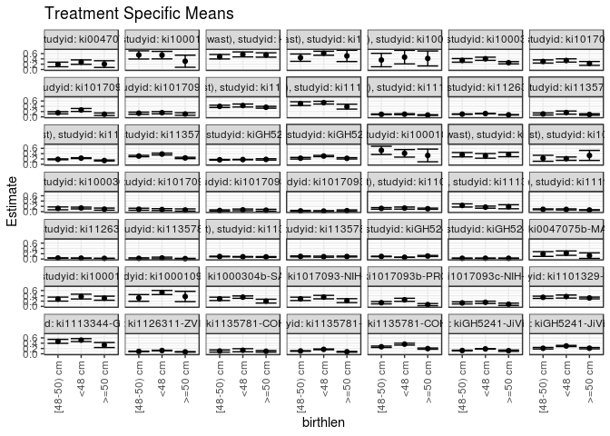

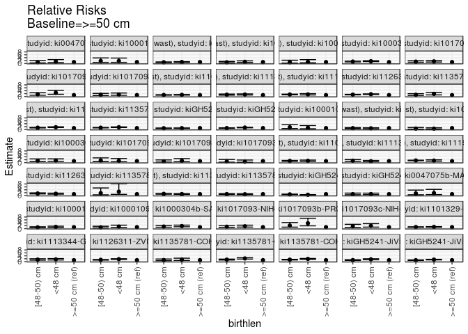

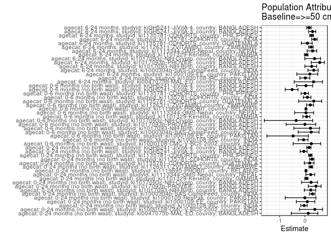

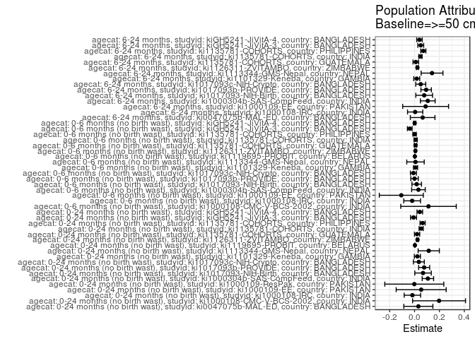

## Results Table

### Parameter: TSM

| agecat | studyid | country | intervention_level | baseline_level | estimate | ci_lower | ci_upper |
| --- | --- | --- | --- | --- | --- | --- | --- |
| 0-24 months (no birth wast) | ki0047075b-MAL-ED | BANGLADESH | >=50 cm | NA | 0.2051282 | 0.0781213 | 0.3321351 |
| 0-24 months (no birth wast) | ki0047075b-MAL-ED | BANGLADESH | <48 cm | NA | 0.2792793 | 0.1956343 | 0.3629242 |
| 0-24 months (no birth wast) | ki0047075b-MAL-ED | BANGLADESH | [48-50) cm | NA | 0.1898734 | 0.1031985 | 0.2765483 |
| 0-24 months (no birth wast) | ki1000108-CMC-V-BCS-2002 | INDIA | >=50 cm | NA | 0.3125000 | 0.0842832 | 0.5407168 |
| 0-24 months (no birth wast) | ki1000108-CMC-V-BCS-2002 | INDIA | <48 cm | NA | 0.5416667 | 0.4000278 | 0.6833055 |
| 0-24 months (no birth wast) | ki1000108-CMC-V-BCS-2002 | INDIA | [48-50) cm | NA | 0.5500000 | 0.3950813 | 0.7049187 |
| 0-24 months (no birth wast) | ki1000108-IRC | INDIA | >=50 cm | NA | 0.5481396 | 0.4656255 | 0.6306538 |
| 0-24 months (no birth wast) | ki1000108-IRC | INDIA | <48 cm | NA | 0.5692728 | 0.4757017 | 0.6628440 |
| 0-24 months (no birth wast) | ki1000108-IRC | INDIA | [48-50) cm | NA | 0.4825967 | 0.3982460 | 0.5669473 |
| 0-24 months (no birth wast) | ki1000109-EE | PAKISTAN | >=50 cm | NA | 0.5133137 | 0.3011574 | 0.7254701 |
| 0-24 months (no birth wast) | ki1000109-EE | PAKISTAN | <48 cm | NA | 0.6143034 | 0.5390016 | 0.6896052 |
| 0-24 months (no birth wast) | ki1000109-EE | PAKISTAN | [48-50) cm | NA | 0.4466062 | 0.3088241 | 0.5843883 |
| 0-24 months (no birth wast) | ki1000109-ResPak | PAKISTAN | >=50 cm | NA | 0.4166667 | 0.1342618 | 0.6990715 |
| 0-24 months (no birth wast) | ki1000109-ResPak | PAKISTAN | <48 cm | NA | 0.4666667 | 0.2110630 | 0.7222704 |
| 0-24 months (no birth wast) | ki1000109-ResPak | PAKISTAN | [48-50) cm | NA | 0.3571429 | 0.1030314 | 0.6112543 |
| 0-24 months (no birth wast) | ki1000304b-SAS-CompFeed | INDIA | >=50 cm | NA | 0.2553086 | 0.2119132 | 0.2987039 |
| 0-24 months (no birth wast) | ki1000304b-SAS-CompFeed | INDIA | <48 cm | NA | 0.4045175 | 0.3450158 | 0.4640191 |
| 0-24 months (no birth wast) | ki1000304b-SAS-CompFeed | INDIA | [48-50) cm | NA | 0.3441775 | 0.2754055 | 0.4129496 |
| 0-24 months (no birth wast) | ki1017093-NIH-Birth | BANGLADESH | >=50 cm | NA | 0.2295448 | 0.1563337 | 0.3027559 |
| 0-24 months (no birth wast) | ki1017093-NIH-Birth | BANGLADESH | <48 cm | NA | 0.3404416 | 0.2788648 | 0.4020185 |
| 0-24 months (no birth wast) | ki1017093-NIH-Birth | BANGLADESH | [48-50) cm | NA | 0.3022402 | 0.2418823 | 0.3625981 |
| 0-24 months (no birth wast) | ki1017093b-PROVIDE | BANGLADESH | >=50 cm | NA | 0.1004069 | 0.0536621 | 0.1471517 |
| 0-24 months (no birth wast) | ki1017093b-PROVIDE | BANGLADESH | <48 cm | NA | 0.2608104 | 0.2047252 | 0.3168957 |
| 0-24 months (no birth wast) | ki1017093b-PROVIDE | BANGLADESH | [48-50) cm | NA | 0.1543778 | 0.1118814 | 0.1968743 |
| 0-24 months (no birth wast) | ki1017093c-NIH-Crypto | BANGLADESH | >=50 cm | NA | 0.1087271 | 0.0604984 | 0.1569559 |
| 0-24 months (no birth wast) | ki1017093c-NIH-Crypto | BANGLADESH | <48 cm | NA | 0.1574273 | 0.1148193 | 0.2000354 |
| 0-24 months (no birth wast) | ki1017093c-NIH-Crypto | BANGLADESH | [48-50) cm | NA | 0.1387290 | 0.0988191 | 0.1786388 |
| 0-24 months (no birth wast) | ki1101329-Keneba | GAMBIA | >=50 cm | NA | 0.3639195 | 0.3297566 | 0.3980824 |
| 0-24 months (no birth wast) | ki1101329-Keneba | GAMBIA | <48 cm | NA | 0.4284146 | 0.3716742 | 0.4851550 |
| 0-24 months (no birth wast) | ki1101329-Keneba | GAMBIA | [48-50) cm | NA | 0.3977949 | 0.3546179 | 0.4409720 |

[output cut: 117 more lines]

### Parameter: E(Y)

| agecat | studyid | country | intervention_level | baseline_level | estimate | ci_lower | ci_upper |
| --- | --- | --- | --- | --- | --- | --- | --- |
| 0-24 months (no birth wast) | ki0047075b-MAL-ED | BANGLADESH | NA | NA | 0.2358079 | 0.1807067 | 0.2909091 |
| 0-24 months (no birth wast) | ki1000108-CMC-V-BCS-2002 | INDIA | NA | NA | 0.5096154 | 0.4130727 | 0.6061580 |
| 0-24 months (no birth wast) | ki1000108-IRC | INDIA | NA | NA | 0.5307692 | 0.4811763 | 0.5803621 |
| 0-24 months (no birth wast) | ki1000109-EE | PAKISTAN | NA | NA | 0.5666667 | 0.5038429 | 0.6294904 |
| 0-24 months (no birth wast) | ki1000109-ResPak | PAKISTAN | NA | NA | 0.4146341 | 0.2619604 | 0.5673079 |
| 0-24 months (no birth wast) | ki1000304b-SAS-CompFeed | INDIA | NA | NA | 0.3626595 | 0.3120201 | 0.4132989 |
| 0-24 months (no birth wast) | ki1017093-NIH-Birth | BANGLADESH | NA | NA | 0.2977625 | 0.2605481 | 0.3349769 |
| 0-24 months (no birth wast) | ki1017093b-PROVIDE | BANGLADESH | NA | NA | 0.1775837 | 0.1489858 | 0.2061816 |
| 0-24 months (no birth wast) | ki1017093c-NIH-Crypto | BANGLADESH | NA | NA | 0.1432361 | 0.1182149 | 0.1682572 |
| 0-24 months (no birth wast) | ki1101329-Keneba | GAMBIA | NA | NA | 0.3865546 | 0.3622809 | 0.4108284 |
| 0-24 months (no birth wast) | ki1113344-GMS-Nepal | NEPAL | NA | NA | 0.5007587 | 0.4625551 | 0.5389624 |
| 0-24 months (no birth wast) | ki1119695-PROBIT | BELARUS | NA | NA | 0.0716952 | 0.0597165 | 0.0836739 |
| 0-24 months (no birth wast) | ki1126311-ZVITAMBO | ZIMBABWE | NA | NA | 0.1019924 | 0.0968873 | 0.1070976 |
| 0-24 months (no birth wast) | ki1135781-COHORTS | GUATEMALA | NA | NA | 0.1096224 | 0.0882390 | 0.1310059 |
| 0-24 months (no birth wast) | ki1135781-COHORTS | INDIA | NA | NA | 0.1948438 | 0.1851392 | 0.2045483 |
| 0-24 months (no birth wast) | ki1135781-COHORTS | PHILIPPINES | NA | NA | 0.3035536 | 0.2871278 | 0.3199794 |
| 0-24 months (no birth wast) | kiGH5241-JiVitA-3 | BANGLADESH | NA | NA | 0.1757133 | 0.1696451 | 0.1817815 |
| 0-24 months (no birth wast) | kiGH5241-JiVitA-4 | BANGLADESH | NA | NA | 0.2663530 | 0.2512746 | 0.2814315 |
| 0-6 months (no birth wast) | ki1000108-CMC-V-BCS-2002 | INDIA | NA | NA | 0.4455446 | 0.3481293 | 0.5429598 |
| 0-6 months (no birth wast) | ki1000108-IRC | INDIA | NA | NA | 0.3494624 | 0.3009450 | 0.3979798 |
| 0-6 months (no birth wast) | ki1000109-EE | PAKISTAN | NA | NA | 0.2268908 | 0.1735692 | 0.2802123 |
| 0-6 months (no birth wast) | ki1000304b-SAS-CompFeed | INDIA | NA | NA | 0.1264525 | 0.0961151 | 0.1567899 |
| 0-6 months (no birth wast) | ki1017093-NIH-Birth | BANGLADESH | NA | NA | 0.0797872 | 0.0574049 | 0.1021695 |
| 0-6 months (no birth wast) | ki1017093b-PROVIDE | BANGLADESH | NA | NA | 0.0541728 | 0.0371844 | 0.0711612 |
| 0-6 months (no birth wast) | ki1017093c-NIH-Crypto | BANGLADESH | NA | NA | 0.0267023 | 0.0151493 | 0.0382553 |
| 0-6 months (no birth wast) | ki1101329-Keneba | GAMBIA | NA | NA | 0.1187215 | 0.1025243 | 0.1349187 |
| 0-6 months (no birth wast) | ki1113344-GMS-Nepal | NEPAL | NA | NA | 0.1918877 | 0.1613794 | 0.2223959 |
| 0-6 months (no birth wast) | ki1119695-PROBIT | BELARUS | NA | NA | 0.0637570 | 0.0524446 | 0.0750694 |
| 0-6 months (no birth wast) | ki1126311-ZVITAMBO | ZIMBABWE | NA | NA | 0.0322167 | 0.0292105 | 0.0352229 |
| 0-6 months (no birth wast) | ki1135781-COHORTS | GUATEMALA | NA | NA | 0.0226986 | 0.0123257 | 0.0330715 |
| 0-6 months (no birth wast) | ki1135781-COHORTS | INDIA | NA | NA | 0.0882353 | 0.0810887 | 0.0953819 |
| 0-6 months (no birth wast) | ki1135781-COHORTS | PHILIPPINES | NA | NA | 0.0946488 | 0.0841546 | 0.1051431 |
| 0-6 months (no birth wast) | kiGH5241-JiVitA-3 | BANGLADESH | NA | NA | 0.0760414 | 0.0718411 | 0.0802418 |
| 0-6 months (no birth wast) | kiGH5241-JiVitA-4 | BANGLADESH | NA | NA | 0.0289057 | 0.0236101 | 0.0342013 |
| 6-24 months | ki0047075b-MAL-ED | BANGLADESH | NA | NA | 0.1933962 | 0.1401044 | 0.2466881 |
| 6-24 months | ki1000108-IRC | INDIA | NA | NA | 0.3145780 | 0.2684931 | 0.3606629 |
| 6-24 months | ki1000109-EE | PAKISTAN | NA | NA | 0.4641350 | 0.4005079 | 0.5277621 |
| 6-24 months | ki1000304b-SAS-CompFeed | INDIA | NA | NA | 0.3059593 | 0.2629068 | 0.3490118 |
| 6-24 months | ki1017093-NIH-Birth | BANGLADESH | NA | NA | 0.2950192 | 0.2558591 | 0.3341792 |
| 6-24 months | ki1017093b-PROVIDE | BANGLADESH | NA | NA | 0.1609756 | 0.1319065 | 0.1900447 |
| 6-24 months | ki1017093c-NIH-Crypto | BANGLADESH | NA | NA | 0.1315068 | 0.1069744 | 0.1560393 |
| 6-24 months | ki1101329-Keneba | GAMBIA | NA | NA | 0.3362475 | 0.3122276 | 0.3602674 |
| 6-24 months | ki1113344-GMS-Nepal | NEPAL | NA | NA | 0.4719864 | 0.4316361 | 0.5123367 |
| 6-24 months | ki1126311-ZVITAMBO | ZIMBABWE | NA | NA | 0.0956969 | 0.0901201 | 0.1012737 |
| 6-24 months | ki1135781-COHORTS | GUATEMALA | NA | NA | 0.1059147 | 0.0835302 | 0.1282992 |
| 6-24 months | ki1135781-COHORTS | INDIA | NA | NA | 0.1236829 | 0.1154669 | 0.1318989 |
| 6-24 months | ki1135781-COHORTS | PHILIPPINES | NA | NA | 0.2665953 | 0.2502200 | 0.2829706 |
| 6-24 months | kiGH5241-JiVitA-3 | BANGLADESH | NA | NA | 0.1671558 | 0.1603545 | 0.1739571 |
| 6-24 months | kiGH5241-JiVitA-4 | BANGLADESH | NA | NA | 0.2510058 | 0.2361044 | 0.2659072 |

### Parameter: RR

| agecat | studyid | country | intervention_level | baseline_level | estimate | ci_lower | ci_upper |
| --- | --- | --- | --- | --- | --- | --- | --- |
| 0-24 months (no birth wast) | ki0047075b-MAL-ED | BANGLADESH | >=50 cm | >=50 cm | 1.0000000 | 1.0000000 | 1.0000000 |
| 0-24 months (no birth wast) | ki0047075b-MAL-ED | BANGLADESH | <48 cm | >=50 cm | 1.3614865 | 0.6843977 | 2.7084331 |
| 0-24 months (no birth wast) | ki0047075b-MAL-ED | BANGLADESH | [48-50) cm | >=50 cm | 0.9256329 | 0.4289036 | 1.9976429 |
| 0-24 months (no birth wast) | ki1000108-CMC-V-BCS-2002 | INDIA | >=50 cm | >=50 cm | 1.0000000 | 1.0000000 | 1.0000000 |
| 0-24 months (no birth wast) | ki1000108-CMC-V-BCS-2002 | INDIA | <48 cm | >=50 cm | 1.7333333 | 0.7979976 | 3.7649791 |
| 0-24 months (no birth wast) | ki1000108-CMC-V-BCS-2002 | INDIA | [48-50) cm | >=50 cm | 1.7600000 | 0.8045947 | 3.8498887 |
| 0-24 months (no birth wast) | ki1000108-IRC | INDIA | >=50 cm | >=50 cm | 1.0000000 | 1.0000000 | 1.0000000 |
| 0-24 months (no birth wast) | ki1000108-IRC | INDIA | <48 cm | >=50 cm | 1.0385544 | 0.8308006 | 1.2982600 |
| 0-24 months (no birth wast) | ki1000108-IRC | INDIA | [48-50) cm | >=50 cm | 0.8804265 | 0.6988118 | 1.1092411 |
| 0-24 months (no birth wast) | ki1000109-EE | PAKISTAN | >=50 cm | >=50 cm | 1.0000000 | 1.0000000 | 1.0000000 |
| 0-24 months (no birth wast) | ki1000109-EE | PAKISTAN | <48 cm | >=50 cm | 1.1967406 | 0.7780920 | 1.8406411 |
| 0-24 months (no birth wast) | ki1000109-EE | PAKISTAN | [48-50) cm | >=50 cm | 0.8700453 | 0.5195863 | 1.4568876 |
| 0-24 months (no birth wast) | ki1000109-ResPak | PAKISTAN | >=50 cm | >=50 cm | 1.0000000 | 1.0000000 | 1.0000000 |
| 0-24 months (no birth wast) | ki1000109-ResPak | PAKISTAN | <48 cm | >=50 cm | 1.1200000 | 0.4685596 | 2.6771410 |
| 0-24 months (no birth wast) | ki1000109-ResPak | PAKISTAN | [48-50) cm | >=50 cm | 0.8571429 | 0.3208401 | 2.2899064 |
| 0-24 months (no birth wast) | ki1000304b-SAS-CompFeed | INDIA | >=50 cm | >=50 cm | 1.0000000 | 1.0000000 | 1.0000000 |
| 0-24 months (no birth wast) | ki1000304b-SAS-CompFeed | INDIA | <48 cm | >=50 cm | 1.5844259 | 1.3228216 | 1.8977656 |
| 0-24 months (no birth wast) | ki1000304b-SAS-CompFeed | INDIA | [48-50) cm | >=50 cm | 1.3480845 | 1.0985599 | 1.6542857 |
| 0-24 months (no birth wast) | ki1017093-NIH-Birth | BANGLADESH | >=50 cm | >=50 cm | 1.0000000 | 1.0000000 | 1.0000000 |
| 0-24 months (no birth wast) | ki1017093-NIH-Birth | BANGLADESH | <48 cm | >=50 cm | 1.4831163 | 1.0273643 | 2.1410457 |
| 0-24 months (no birth wast) | ki1017093-NIH-Birth | BANGLADESH | [48-50) cm | >=50 cm | 1.3166937 | 0.9039636 | 1.9178673 |
| 0-24 months (no birth wast) | ki1017093b-PROVIDE | BANGLADESH | >=50 cm | >=50 cm | 1.0000000 | 1.0000000 | 1.0000000 |
| 0-24 months (no birth wast) | ki1017093b-PROVIDE | BANGLADESH | <48 cm | >=50 cm | 2.5975348 | 1.5552785 | 4.3382503 |
| 0-24 months (no birth wast) | ki1017093b-PROVIDE | BANGLADESH | [48-50) cm | >=50 cm | 1.5375222 | 0.8954705 | 2.6399246 |
| 0-24 months (no birth wast) | ki1017093c-NIH-Crypto | BANGLADESH | >=50 cm | >=50 cm | 1.0000000 | 1.0000000 | 1.0000000 |
| 0-24 months (no birth wast) | ki1017093c-NIH-Crypto | BANGLADESH | <48 cm | >=50 cm | 1.4479119 | 0.8611921 | 2.4343568 |
| 0-24 months (no birth wast) | ki1017093c-NIH-Crypto | BANGLADESH | [48-50) cm | >=50 cm | 1.2759370 | 0.7515862 | 2.1661059 |
| 0-24 months (no birth wast) | ki1101329-Keneba | GAMBIA | >=50 cm | >=50 cm | 1.0000000 | 1.0000000 | 1.0000000 |
| 0-24 months (no birth wast) | ki1101329-Keneba | GAMBIA | <48 cm | >=50 cm | 1.1772234 | 1.0016753 | 1.3835371 |
| 0-24 months (no birth wast) | ki1101329-Keneba | GAMBIA | [48-50) cm | >=50 cm | 1.0930849 | 0.9475407 | 1.2609850 |

[output cut: 117 more lines]

### Parameter: PAR

| agecat | studyid | country | intervention_level | baseline_level | estimate | ci_lower | ci_upper |
| --- | --- | --- | --- | --- | --- | --- | --- |
| 0-24 months (no birth wast) | ki0047075b-MAL-ED | BANGLADESH | >=50 cm | NA | 0.0306797 | -0.0862501 | 0.1476095 |
| 0-24 months (no birth wast) | ki1000108-CMC-V-BCS-2002 | INDIA | >=50 cm | NA | 0.1971154 | -0.0159054 | 0.4101362 |
| 0-24 months (no birth wast) | ki1000108-IRC | INDIA | >=50 cm | NA | -0.0173704 | -0.0833846 | 0.0486437 |
| 0-24 months (no birth wast) | ki1000109-EE | PAKISTAN | >=50 cm | NA | 0.0533529 | -0.1478681 | 0.2545740 |
| 0-24 months (no birth wast) | ki1000109-ResPak | PAKISTAN | >=50 cm | NA | -0.0020325 | -0.2394717 | 0.2354067 |
| 0-24 months (no birth wast) | ki1000304b-SAS-CompFeed | INDIA | >=50 cm | NA | 0.1073509 | 0.0612281 | 0.1534738 |
| 0-24 months (no birth wast) | ki1017093-NIH-Birth | BANGLADESH | >=50 cm | NA | 0.0682177 | 0.0020425 | 0.1343928 |
| 0-24 months (no birth wast) | ki1017093b-PROVIDE | BANGLADESH | >=50 cm | NA | 0.0771768 | 0.0328271 | 0.1215265 |
| 0-24 months (no birth wast) | ki1017093c-NIH-Crypto | BANGLADESH | >=50 cm | NA | 0.0345089 | -0.0094062 | 0.0784240 |
| 0-24 months (no birth wast) | ki1101329-Keneba | GAMBIA | >=50 cm | NA | 0.0226351 | -0.0018245 | 0.0470947 |
| 0-24 months (no birth wast) | ki1113344-GMS-Nepal | NEPAL | >=50 cm | NA | 0.1142069 | 0.0288458 | 0.1995680 |
| 0-24 months (no birth wast) | ki1119695-PROBIT | BELARUS | >=50 cm | NA | 0.0028919 | 0.0013330 | 0.0044509 |
| 0-24 months (no birth wast) | ki1126311-ZVITAMBO | ZIMBABWE | >=50 cm | NA | 0.0240195 | 0.0165891 | 0.0314499 |
| 0-24 months (no birth wast) | ki1135781-COHORTS | GUATEMALA | >=50 cm | NA | 0.0205056 | -0.0004688 | 0.0414800 |
| 0-24 months (no birth wast) | ki1135781-COHORTS | INDIA | >=50 cm | NA | 0.0533038 | 0.0364404 | 0.0701673 |
| 0-24 months (no birth wast) | ki1135781-COHORTS | PHILIPPINES | >=50 cm | NA | 0.0647160 | 0.0440468 | 0.0853852 |
| 0-24 months (no birth wast) | kiGH5241-JiVitA-3 | BANGLADESH | >=50 cm | NA | -0.0079460 | -0.0319460 | 0.0160540 |
| 0-24 months (no birth wast) | kiGH5241-JiVitA-4 | BANGLADESH | >=50 cm | NA | 0.0421793 | 0.0196260 | 0.0647326 |
| 0-6 months (no birth wast) | ki1000108-CMC-V-BCS-2002 | INDIA | >=50 cm | NA | 0.1122112 | -0.1111633 | 0.3355858 |
| 0-6 months (no birth wast) | ki1000108-IRC | INDIA | >=50 cm | NA | -0.0192679 | -0.0864614 | 0.0479256 |
| 0-6 months (no birth wast) | ki1000109-EE | PAKISTAN | >=50 cm | NA | -0.1064426 | -0.2835258 | 0.0706407 |
| 0-6 months (no birth wast) | ki1000304b-SAS-CompFeed | INDIA | >=50 cm | NA | 0.0312693 | -0.0233813 | 0.0859199 |
| 0-6 months (no birth wast) | ki1017093-NIH-Birth | BANGLADESH | >=50 cm | NA | 0.0172872 | -0.0209617 | 0.0555361 |
| 0-6 months (no birth wast) | ki1017093b-PROVIDE | BANGLADESH | >=50 cm | NA | -0.0000441 | -0.0300327 | 0.0299445 |
| 0-6 months (no birth wast) | ki1017093c-NIH-Crypto | BANGLADESH | >=50 cm | NA | -0.0092259 | -0.0332159 | 0.0147641 |
| 0-6 months (no birth wast) | ki1101329-Keneba | GAMBIA | >=50 cm | NA | 0.0080288 | -0.0085394 | 0.0245969 |
| 0-6 months (no birth wast) | ki1113344-GMS-Nepal | NEPAL | >=50 cm | NA | 0.0075509 | -0.0626557 | 0.0777576 |
| 0-6 months (no birth wast) | ki1119695-PROBIT | BELARUS | >=50 cm | NA | 0.0024874 | 0.0012360 | 0.0037387 |
| 0-6 months (no birth wast) | ki1126311-ZVITAMBO | ZIMBABWE | >=50 cm | NA | 0.0068635 | 0.0024481 | 0.0112790 |
| 0-6 months (no birth wast) | ki1135781-COHORTS | GUATEMALA | >=50 cm | NA | 0.0078838 | -0.0023448 | 0.0181124 |
| 0-6 months (no birth wast) | ki1135781-COHORTS | INDIA | >=50 cm | NA | 0.0085830 | -0.0046038 | 0.0217699 |
| 0-6 months (no birth wast) | ki1135781-COHORTS | PHILIPPINES | >=50 cm | NA | 0.0002654 | -0.0133262 | 0.0138570 |
| 0-6 months (no birth wast) | kiGH5241-JiVitA-3 | BANGLADESH | >=50 cm | NA | -0.0384932 | -0.0575256 | -0.0194608 |
| 0-6 months (no birth wast) | kiGH5241-JiVitA-4 | BANGLADESH | >=50 cm | NA | 0.0011141 | -0.0078084 | 0.0100366 |
| 6-24 months | ki0047075b-MAL-ED | BANGLADESH | >=50 cm | NA | 0.0651911 | -0.0339632 | 0.1643454 |
| 6-24 months | ki1000108-IRC | INDIA | >=50 cm | NA | 0.0048507 | -0.0564559 | 0.0661573 |
| 6-24 months | ki1000109-EE | PAKISTAN | >=50 cm | NA | 0.0891350 | -0.0955041 | 0.2737741 |
| 6-24 months | ki1000304b-SAS-CompFeed | INDIA | >=50 cm | NA | 0.1065093 | 0.0473496 | 0.1656690 |
| 6-24 months | ki1017093-NIH-Birth | BANGLADESH | >=50 cm | NA | 0.0775030 | 0.0101943 | 0.1448117 |
| 6-24 months | ki1017093b-PROVIDE | BANGLADESH | >=50 cm | NA | 0.0933095 | 0.0511855 | 0.1354335 |
| 6-24 months | ki1017093c-NIH-Crypto | BANGLADESH | >=50 cm | NA | 0.0497008 | 0.0095327 | 0.0898689 |
| 6-24 months | ki1101329-Keneba | GAMBIA | >=50 cm | NA | 0.0174895 | -0.0062953 | 0.0412743 |
| 6-24 months | ki1113344-GMS-Nepal | NEPAL | >=50 cm | NA | 0.1406580 | 0.0528478 | 0.2284682 |
| 6-24 months | ki1126311-ZVITAMBO | ZIMBABWE | >=50 cm | NA | 0.0230394 | 0.0147692 | 0.0313095 |
| 6-24 months | ki1135781-COHORTS | GUATEMALA | >=50 cm | NA | 0.0101434 | -0.0122848 | 0.0325717 |
| 6-24 months | ki1135781-COHORTS | INDIA | >=50 cm | NA | 0.0472516 | 0.0337305 | 0.0607728 |
| 6-24 months | ki1135781-COHORTS | PHILIPPINES | >=50 cm | NA | 0.0705923 | 0.0501608 | 0.0910237 |
| 6-24 months | kiGH5241-JiVitA-3 | BANGLADESH | >=50 cm | NA | 0.0499508 | 0.0263818 | 0.0735198 |
| 6-24 months | kiGH5241-JiVitA-4 | BANGLADESH | >=50 cm | NA | 0.0397648 | 0.0176874 | 0.0618423 |

### Parameter: PAF

| agecat | studyid | country | intervention_level | baseline_level | estimate | ci_lower | ci_upper |
| --- | --- | --- | --- | --- | --- | --- | --- |
| 0-24 months (no birth wast) | ki0047075b-MAL-ED | BANGLADESH | >=50 cm | NA | 0.1301045 | -0.5374946 | 0.5078238 |
| 0-24 months (no birth wast) | ki1000108-CMC-V-BCS-2002 | INDIA | >=50 cm | NA | 0.3867925 | -0.2158991 | 0.6907445 |
| 0-24 months (no birth wast) | ki1000108-IRC | INDIA | >=50 cm | NA | -0.0327269 | -0.1649477 | 0.0844870 |
| 0-24 months (no birth wast) | ki1000109-EE | PAKISTAN | >=50 cm | NA | 0.0941522 | -0.3411810 | 0.3881809 |
| 0-24 months (no birth wast) | ki1000109-ResPak | PAKISTAN | >=50 cm | NA | -0.0049020 | -0.7766780 | 0.4316202 |
| 0-24 months (no birth wast) | ki1000304b-SAS-CompFeed | INDIA | >=50 cm | NA | 0.2960103 | 0.1798369 | 0.3957281 |
| 0-24 months (no birth wast) | ki1017093-NIH-Birth | BANGLADESH | >=50 cm | NA | 0.2291010 | -0.0278144 | 0.4217971 |
| 0-24 months (no birth wast) | ki1017093b-PROVIDE | BANGLADESH | >=50 cm | NA | 0.4345940 | 0.1311583 | 0.6320573 |
| 0-24 months (no birth wast) | ki1017093c-NIH-Crypto | BANGLADESH | >=50 cm | NA | 0.2409234 | -0.1346030 | 0.4921596 |
| 0-24 months (no birth wast) | ki1101329-Keneba | GAMBIA | >=50 cm | NA | 0.0585560 | -0.0069417 | 0.1197933 |
| 0-24 months (no birth wast) | ki1113344-GMS-Nepal | NEPAL | >=50 cm | NA | 0.2280677 | 0.0367525 | 0.3813849 |
| 0-24 months (no birth wast) | ki1119695-PROBIT | BELARUS | >=50 cm | NA | 0.0403366 | 0.0157566 | 0.0643027 |
| 0-24 months (no birth wast) | ki1126311-ZVITAMBO | ZIMBABWE | >=50 cm | NA | 0.2355030 | 0.1599236 | 0.3042827 |
| 0-24 months (no birth wast) | ki1135781-COHORTS | GUATEMALA | >=50 cm | NA | 0.1870563 | -0.0257758 | 0.3557292 |
| 0-24 months (no birth wast) | ki1135781-COHORTS | INDIA | >=50 cm | NA | 0.2735723 | 0.1823937 | 0.3545827 |
| 0-24 months (no birth wast) | ki1135781-COHORTS | PHILIPPINES | >=50 cm | NA | 0.2131947 | 0.1423802 | 0.2781619 |
| 0-24 months (no birth wast) | kiGH5241-JiVitA-3 | BANGLADESH | >=50 cm | NA | -0.0452214 | -0.1911963 | 0.0828650 |
| 0-24 months (no birth wast) | kiGH5241-JiVitA-4 | BANGLADESH | >=50 cm | NA | 0.1583588 | 0.0698767 | 0.2384236 |
| 0-6 months (no birth wast) | ki1000108-CMC-V-BCS-2002 | INDIA | >=50 cm | NA | 0.2518519 | -0.4634357 | 0.6175263 |
| 0-6 months (no birth wast) | ki1000108-IRC | INDIA | >=50 cm | NA | -0.0551358 | -0.2659878 | 0.1205985 |
| 0-6 months (no birth wast) | ki1000109-EE | PAKISTAN | >=50 cm | NA | -0.4691358 | -1.4972590 | 0.1357084 |
| 0-6 months (no birth wast) | ki1000304b-SAS-CompFeed | INDIA | >=50 cm | NA | 0.2472812 | -0.2681419 | 0.5532159 |
| 0-6 months (no birth wast) | ki1017093-NIH-Birth | BANGLADESH | >=50 cm | NA | 0.2166667 | -0.4383833 | 0.5734022 |
| 0-6 months (no birth wast) | ki1017093b-PROVIDE | BANGLADESH | >=50 cm | NA | -0.0008140 | -0.7400908 | 0.4243813 |
| 0-6 months (no birth wast) | ki1017093c-NIH-Crypto | BANGLADESH | >=50 cm | NA | -0.3455090 | -1.6009534 | 0.3039497 |
| 0-6 months (no birth wast) | ki1101329-Keneba | GAMBIA | >=50 cm | NA | 0.0676270 | -0.0827052 | 0.1970857 |
| 0-6 months (no birth wast) | ki1113344-GMS-Nepal | NEPAL | >=50 cm | NA | 0.0393508 | -0.4059639 | 0.3436198 |
| 0-6 months (no birth wast) | ki1119695-PROBIT | BELARUS | >=50 cm | NA | 0.0390131 | 0.0175968 | 0.0599625 |
| 0-6 months (no birth wast) | ki1126311-ZVITAMBO | ZIMBABWE | >=50 cm | NA | 0.2130423 | 0.0649294 | 0.3376945 |
| 0-6 months (no birth wast) | ki1135781-COHORTS | GUATEMALA | >=50 cm | NA | 0.3473251 | -0.2471956 | 0.6584461 |
| 0-6 months (no birth wast) | ki1135781-COHORTS | INDIA | >=50 cm | NA | 0.0972745 | -0.0650592 | 0.2348657 |
| 0-6 months (no birth wast) | ki1135781-COHORTS | PHILIPPINES | >=50 cm | NA | 0.0028043 | -0.1516522 | 0.1365455 |
| 0-6 months (no birth wast) | kiGH5241-JiVitA-3 | BANGLADESH | >=50 cm | NA | -0.5062132 | -0.7777161 | -0.2761758 |
| 0-6 months (no birth wast) | kiGH5241-JiVitA-4 | BANGLADESH | >=50 cm | NA | 0.0385415 | -0.3260853 | 0.3029088 |
| 6-24 months | ki0047075b-MAL-ED | BANGLADESH | >=50 cm | NA | 0.3370857 | -0.4241671 | 0.6914299 |
| 6-24 months | ki1000108-IRC | INDIA | >=50 cm | NA | 0.0154196 | -0.2001023 | 0.1922367 |
| 6-24 months | ki1000109-EE | PAKISTAN | >=50 cm | NA | 0.1920455 | -0.3225373 | 0.5064105 |
| 6-24 months | ki1000304b-SAS-CompFeed | INDIA | >=50 cm | NA | 0.3481159 | 0.1169472 | 0.5187685 |
| 6-24 months | ki1017093-NIH-Birth | BANGLADESH | >=50 cm | NA | 0.2627050 | -0.0038632 | 0.4584880 |
| 6-24 months | ki1017093b-PROVIDE | BANGLADESH | >=50 cm | NA | 0.5796499 | 0.2479394 | 0.7650533 |
| 6-24 months | ki1017093c-NIH-Crypto | BANGLADESH | >=50 cm | NA | 0.3779334 | -0.0072447 | 0.6158164 |
| 6-24 months | ki1101329-Keneba | GAMBIA | >=50 cm | NA | 0.0520137 | -0.0214602 | 0.1202025 |
| 6-24 months | ki1113344-GMS-Nepal | NEPAL | >=50 cm | NA | 0.2980129 | 0.0842439 | 0.4618808 |
| 6-24 months | ki1126311-ZVITAMBO | ZIMBABWE | >=50 cm | NA | 0.2407535 | 0.1502515 | 0.3216166 |
| 6-24 months | ki1135781-COHORTS | GUATEMALA | >=50 cm | NA | 0.0957697 | -0.1418880 | 0.2839645 |
| 6-24 months | ki1135781-COHORTS | INDIA | >=50 cm | NA | 0.3820385 | 0.2651674 | 0.4803218 |
| 6-24 months | ki1135781-COHORTS | PHILIPPINES | >=50 cm | NA | 0.2647918 | 0.1847972 | 0.3369367 |
| 6-24 months | kiGH5241-JiVitA-3 | BANGLADESH | >=50 cm | NA | 0.2988276 | 0.1420225 | 0.4269748 |
| 6-24 months | kiGH5241-JiVitA-4 | BANGLADESH | >=50 cm | NA | 0.1584219 | 0.0662804 | 0.2414706 |